# Project: FBI Gun Data

- Introduction
- Data Wrangling
- Exploratory Data Analysis
- Conclusions
- General Resources

## Introduction

> The information was obtained from the FBI's National Instant Criminal Background Check System. The NICS is used to determine whether a prospective buyer is qualified to purchase firearms or explosives. This system is used by gun shops to ensure that each customer does not have a criminal record or is otherwise ineligible to make a purchase. The data has been supplemented with state level data from [census.gov](https://www.google.com/url?q=https://www.census.gov/&sa=D&ust=1532469042127000  
> )
> - The [NICS](https://www.google.com/url?q=https://d17h27t6h515a5.cloudfront.net/topher/2017/November/5a0a4db8_gun-data/gun-data.xlsx&sa=D&ust=1532469042127000) data is contained in a single sheet of an.xlsx file. It includes the number of firearm checks performed by month, state, and type
> - The [U.S. census data](https://www.google.com/url?q=https://d17h27t6h515a5.cloudfront.net/topher/2017/November/5a0a554c_u.s.-census-data/u.s.-census-data.csv&sa=D&ust=1532469042128000) is stored in a.csv file. At the state level, it contains a number of variables. Most variables have only one data point per state (2016), but a few have data for more than one year.

> Background check types included in the FBI gun data include "permit," "permit recheck," "handgun," "long gun," and "multiple" (purchasing more than one gun per background check). Each month and state has a data point that includes all of the variables mentioned above.

```python
# Import packages
import numpy as np
import pandas as pd
import matplotlib.pyplot as plt
import seaborn as sns
%matplotlib inline
```

## Data Wrangling

```python
# Load your data and print out a few lines. Perform operations to inspect data
df_gun_data = pd.read_excel('gun_data.xlsx')
df_census_data = pd.read_csv('U.S. Census Data.csv')
```

```python
# print out a few lines
df_gun_data.head()
```

|  | month | state | permit | permit_recheck | handgun | long_gun | other | multiple | admin | prepawn_handgun | ... | returned_other | rentals_handgun | rentals_long_gun | private_sale_handgun | private_sale_long_gun | private_sale_other | return_to_seller_handgun | return_to_seller_long_gun | return_to_seller_other | totals |
| --- | --- | --- | --- | --- | --- | --- | --- | --- | --- | --- | --- | --- | --- | --- | --- | --- | --- | --- | --- | --- | --- |
| 0 | 2017-09 | Alabama | 16717.0 | 0.0 | 5734.0 | 6320.0 | 221.0 | 317 | 0.0 | 15.0 | ... | 0.0 | 0.0 | 0.0 | 9.0 | 16.0 | 3.0 | 0.0 | 0.0 | 3.0 | 32019 |
| 1 | 2017-09 | Alaska | 209.0 | 2.0 | 2320.0 | 2930.0 | 219.0 | 160 | 0.0 | 5.0 | ... | 0.0 | 0.0 | 0.0 | 17.0 | 24.0 | 1.0 | 0.0 | 0.0 | 0.0 | 6303 |
| 2 | 2017-09 | Arizona | 5069.0 | 382.0 | 11063.0 | 7946.0 | 920.0 | 631 | 0.0 | 13.0 | ... | 0.0 | 0.0 | 0.0 | 38.0 | 12.0 | 2.0 | 0.0 | 0.0 | 0.0 | 28394 |
| 3 | 2017-09 | Arkansas | 2935.0 | 632.0 | 4347.0 | 6063.0 | 165.0 | 366 | 51.0 | 12.0 | ... | 0.0 | 0.0 | 0.0 | 13.0 | 23.0 | 0.0 | 0.0 | 2.0 | 1.0 | 17747 |
| 4 | 2017-09 | California | 57839.0 | 0.0 | 37165.0 | 24581.0 | 2984.0 | 0 | 0.0 | 0.0 | ... | 0.0 | 0.0 | 0.0 | 0.0 | 0.0 | 0.0 | 0.0 | 0.0 | 0.0 | 123506 |

5 rows × 27 columns

```python
# Displaying the the columns' names
df_gun_data.columns.values
```

```
array(['month', 'state', 'permit', 'permit_recheck', 'handgun',
       'long_gun', 'other', 'multiple', 'admin', 'prepawn_handgun',
       'prepawn_long_gun', 'prepawn_other', 'redemption_handgun',
       'redemption_long_gun', 'redemption_other', 'returned_handgun',
       'returned_long_gun', 'returned_other', 'rentals_handgun',
       'rentals_long_gun', 'private_sale_handgun',
       'private_sale_long_gun', 'private_sale_other',
       'return_to_seller_handgun', 'return_to_seller_long_gun',
       'return_to_seller_other', 'totals'], dtype=object)
```

```python
# Check the data records
df_gun_data.shape
```

```
(12485, 27)
```

```python
df_gun_data.describe()
```

|  | permit | permit_recheck | handgun | long_gun | other | multiple | admin | prepawn_handgun | prepawn_long_gun | prepawn_other | ... | returned_other | rentals_handgun | rentals_long_gun | private_sale_handgun | private_sale_long_gun | private_sale_other | return_to_seller_handgun | return_to_seller_long_gun | return_to_seller_other | totals |
| --- | --- | --- | --- | --- | --- | --- | --- | --- | --- | --- | --- | --- | --- | --- | --- | --- | --- | --- | --- | --- | --- |
| count | 12461.000000 | 1100.000000 | 12465.000000 | 12466.000000 | 5500.000000 | 12485.000000 | 12462.000000 | 10542.000000 | 10540.000000 | 5115.000000 | ... | 1815.000000 | 990.000000 | 825.000000 | 2750.000000 | 2750.000000 | 2750.000000 | 2475.000000 | 2750.000000 | 2255.000000 | 12485.000000 |
| mean | 6413.629404 | 1165.956364 | 5940.881107 | 7810.847585 | 360.471636 | 268.603364 | 58.898090 | 4.828021 | 7.834156 | 0.165591 | ... | 1.027548 | 0.076768 | 0.087273 | 14.936000 | 11.602909 | 1.030182 | 0.402020 | 0.441818 | 0.105987 | 21595.725911 |
| std | 23752.338269 | 9224.200609 | 8618.584060 | 9309.846140 | 1349.478273 | 783.185073 | 604.814818 | 10.907756 | 16.468028 | 1.057105 | ... | 4.386296 | 0.634503 | 0.671649 | 71.216021 | 54.253090 | 4.467843 | 1.446568 | 1.528223 | 0.427363 | 32591.418387 |
| min | 0.000000 | 0.000000 | 0.000000 | 0.000000 | 0.000000 | 0.000000 | 0.000000 | 0.000000 | 0.000000 | 0.000000 | ... | 0.000000 | 0.000000 | 0.000000 | 0.000000 | 0.000000 | 0.000000 | 0.000000 | 0.000000 | 0.000000 | 0.000000 |
| 25% | 0.000000 | 0.000000 | 865.000000 | 2078.250000 | 17.000000 | 15.000000 | 0.000000 | 0.000000 | 0.000000 | 0.000000 | ... | 0.000000 | 0.000000 | 0.000000 | 0.000000 | 0.000000 | 0.000000 | 0.000000 | 0.000000 | 0.000000 | 4638.000000 |
| 50% | 518.000000 | 0.000000 | 3059.000000 | 5122.000000 | 121.000000 | 125.000000 | 0.000000 | 0.000000 | 1.000000 | 0.000000 | ... | 0.000000 | 0.000000 | 0.000000 | 0.000000 | 0.000000 | 0.000000 | 0.000000 | 0.000000 | 0.000000 | 12399.000000 |
| 75% | 4272.000000 | 0.000000 | 7280.000000 | 10380.750000 | 354.000000 | 301.000000 | 0.000000 | 5.000000 | 8.000000 | 0.000000 | ... | 0.000000 | 0.000000 | 0.000000 | 2.000000 | 4.000000 | 0.000000 | 0.000000 | 0.000000 | 0.000000 | 25453.000000 |
| max | 522188.000000 | 116681.000000 | 107224.000000 | 108058.000000 | 77929.000000 | 38907.000000 | 28083.000000 | 164.000000 | 269.000000 | 49.000000 | ... | 64.000000 | 12.000000 | 12.000000 | 1017.000000 | 777.000000 | 71.000000 | 28.000000 | 17.000000 | 4.000000 | 541978.000000 |

8 rows × 25 columns

```python
# ckeck for the total number of null values in each column
df_gun_data.isnull().sum()
```

```
month                            0
state                            0
permit                          24
permit_recheck               11385
handgun                         20
long_gun                        19
other                         6985
multiple                         0
admin                           23
prepawn_handgun               1943
prepawn_long_gun              1945
prepawn_other                 7370
redemption_handgun            1940
redemption_long_gun           1941
redemption_other              7370
returned_handgun             10285
returned_long_gun            10340
returned_other               10670
rentals_handgun              11495
rentals_long_gun             11660
private_sale_handgun          9735
private_sale_long_gun         9735
private_sale_other            9735
return_to_seller_handgun     10010
return_to_seller_long_gun     9735
return_to_seller_other       10230
totals                           0
dtype: int64
```

```python
# check the data types of variables in the gun dataset
df_gun_data.info()
```

```
<class 'pandas.core.frame.DataFrame'>
RangeIndex: 12485 entries, 0 to 12484
Data columns (total 27 columns):
 #   Column                     Non-Null Count  Dtype
---  ------                     --------------  -----
 0   month                      12485 non-null  object
 1   state                      12485 non-null  object
 2   permit                     12461 non-null  float64
 3   permit_recheck             1100 non-null   float64
 4   handgun                    12465 non-null  float64
 5   long_gun                   12466 non-null  float64
 6   other                      5500 non-null   float64
 7   multiple                   12485 non-null  int64
 8   admin                      12462 non-null  float64
 9   prepawn_handgun            10542 non-null  float64
```

[output cut: 19 more lines]

```python
# check for the total duplicated values
df_gun_data.duplicated().sum()
```

```
0
```

There are no duplicate values in the gun data

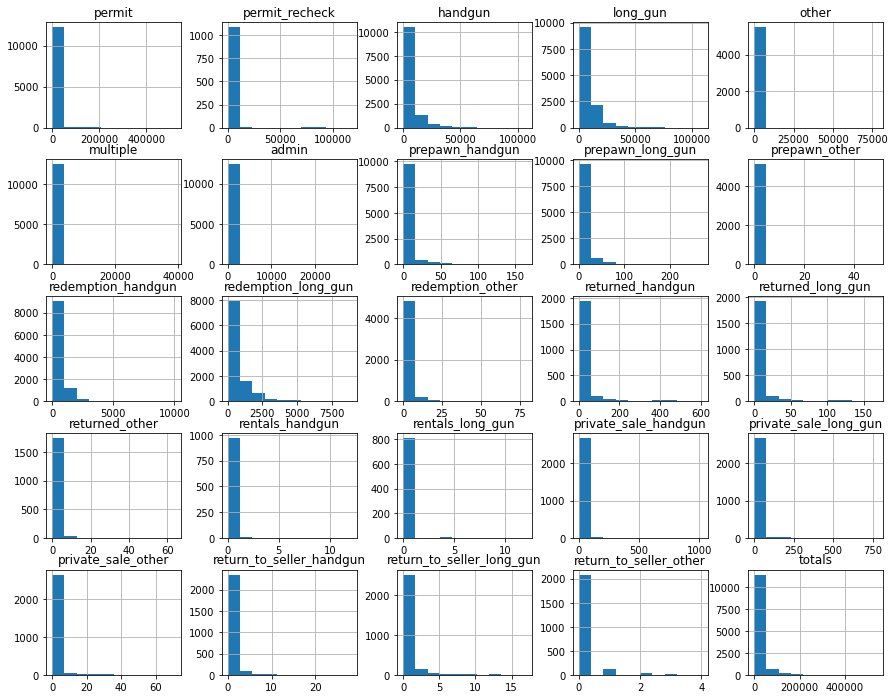

```python
df_gun_data.hist(figsize=(15,12));
```

```python
# print out a few lines of census data
df_census_data.head()
```

|  | Fact | Fact Note | Alabama | Alaska | Arizona | Arkansas | California | Colorado | Connecticut | Delaware | ... | South Dakota | Tennessee | Texas | Utah | Vermont | Virginia | Washington | West Virginia | Wisconsin | Wyoming |
| --- | --- | --- | --- | --- | --- | --- | --- | --- | --- | --- | --- | --- | --- | --- | --- | --- | --- | --- | --- | --- | --- |
| 0 | Population estimates, July 1, 2016, (V2016) | NaN | 4,863,300 | 741,894 | 6,931,071 | 2,988,248 | 39,250,017 | 5,540,545 | 3,576,452 | 952,065 | ... | 865454 | 6651194 | 27,862,596 | 3,051,217 | 624,594 | 8,411,808 | 7,288,000 | 1,831,102 | 5,778,708 | 585,501 |
| 1 | Population estimates base, April 1, 2010, (V2... | NaN | 4,780,131 | 710,249 | 6,392,301 | 2,916,025 | 37,254,522 | 5,029,324 | 3,574,114 | 897,936 | ... | 814195 | 6346298 | 25,146,100 | 2,763,888 | 625,741 | 8,001,041 | 6,724,545 | 1,853,011 | 5,687,289 | 563,767 |
| 2 | Population, percent change - April 1, 2010 (es... | NaN | 1.70% | 4.50% | 8.40% | 2.50% | 5.40% | 10.20% | 0.10% | 6.00% | ... | 0.063 | 0.048 | 10.80% | 10.40% | -0.20% | 5.10% | 8.40% | -1.20% | 1.60% | 3.90% |
| 3 | Population, Census, April 1, 2010 | NaN | 4,779,736 | 710,231 | 6,392,017 | 2,915,918 | 37,253,956 | 5,029,196 | 3,574,097 | 897,934 | ... | 814180 | 6346105 | 25,145,561 | 2,763,885 | 625,741 | 8,001,024 | 6,724,540 | 1,852,994 | 5,686,986 | 563,626 |
| 4 | Persons under 5 years, percent, July 1, 2016, ... | NaN | 6.00% | 7.30% | 6.30% | 6.40% | 6.30% | 6.10% | 5.20% | 5.80% | ... | 0.071 | 0.061 | 7.20% | 8.30% | 4.90% | 6.10% | 6.20% | 5.50% | 5.80% | 6.50% |

5 rows × 52 columns

```python
# Displaying the the columns' names for census data
df_census_data.columns.values
```

```
array(['Fact', 'Fact Note', 'Alabama', 'Alaska', 'Arizona', 'Arkansas',
       'California', 'Colorado', 'Connecticut', 'Delaware', 'Florida',
       'Georgia', 'Hawaii', 'Idaho', 'Illinois', 'Indiana', 'Iowa',
       'Kansas', 'Kentucky', 'Louisiana', 'Maine', 'Maryland',
       'Massachusetts', 'Michigan', 'Minnesota', 'Mississippi',
       'Missouri', 'Montana', 'Nebraska', 'Nevada', 'New Hampshire',
       'New Jersey', 'New Mexico', 'New York', 'North Carolina',
       'North Dakota', 'Ohio', 'Oklahoma', 'Oregon', 'Pennsylvania',
       'Rhode Island', 'South Carolina', 'South Dakota', 'Tennessee',
       'Texas', 'Utah', 'Vermont', 'Virginia', 'Washington',
       'West Virginia', 'Wisconsin', 'Wyoming'], dtype=object)
```

```python
# Check the number of rows and columns
df_census_data.shape
```

```
(85, 52)
```

```python
df_census_data.describe()
```

|  | Fact | Fact Note | Alabama | Alaska | Arizona | Arkansas | California | Colorado | Connecticut | Delaware | ... | South Dakota | Tennessee | Texas | Utah | Vermont | Virginia | Washington | West Virginia | Wisconsin | Wyoming |
| --- | --- | --- | --- | --- | --- | --- | --- | --- | --- | --- | --- | --- | --- | --- | --- | --- | --- | --- | --- | --- | --- |
| count | 80 | 28 | 65 | 65 | 65 | 65 | 65 | 65 | 65 | 65 | ... | 65 | 65 | 65 | 65 | 65 | 65 | 65 | 65 | 65 | 65 |
| unique | 80 | 15 | 65 | 64 | 64 | 64 | 63 | 64 | 63 | 64 | ... | 65 | 64 | 64 | 64 | 63 | 65 | 65 | 64 | 65 | 64 |
| top | Population estimates, July 1, 2016, (V2016) | (c) | 4,863,300 | 7.30% | 50.30% | 50.90% | 6.80% | 3.30% | 0.10% | 51.60% | ... | 865454 | 0.048 | 50.40% | 2.50% | 1.90% | 8,411,808 | 7,288,000 | 1.50% | 5,778,708 | 7.10% |
| freq | 1 | 6 | 1 | 2 | 2 | 2 | 2 | 2 | 2 | 2 | ... | 1 | 2 | 2 | 2 | 2 | 1 | 1 | 2 | 1 | 2 |

4 rows × 52 columns

```python
# check the data types of variables in the census dataset
df_census_data.info()
```

```
<class 'pandas.core.frame.DataFrame'>
RangeIndex: 85 entries, 0 to 84
Data columns (total 52 columns):
 #   Column          Non-Null Count  Dtype
---  ------          --------------  -----
 0   Fact            80 non-null     object
 1   Fact Note       28 non-null     object
 2   Alabama         65 non-null     object
 3   Alaska          65 non-null     object
 4   Arizona         65 non-null     object
 5   Arkansas        65 non-null     object
 6   California      65 non-null     object
 7   Colorado        65 non-null     object
 8   Connecticut     65 non-null     object
 9   Delaware        65 non-null     object
```

[output cut: 44 more lines]

```python
# check for the total duplicated values census data
df_census_data.duplicated().sum()
```

```
3
```

```python
# check for the duplicated rows
df_census_data[df_census_data.duplicated()]
```

|  | Fact | Fact Note | Alabama | Alaska | Arizona | Arkansas | California | Colorado | Connecticut | Delaware | ... | South Dakota | Tennessee | Texas | Utah | Vermont | Virginia | Washington | West Virginia | Wisconsin | Wyoming |
| --- | --- | --- | --- | --- | --- | --- | --- | --- | --- | --- | --- | --- | --- | --- | --- | --- | --- | --- | --- | --- | --- |
| 67 | NaN | NaN | NaN | NaN | NaN | NaN | NaN | NaN | NaN | NaN | ... | NaN | NaN | NaN | NaN | NaN | NaN | NaN | NaN | NaN | NaN |
| 70 | NaN | NaN | NaN | NaN | NaN | NaN | NaN | NaN | NaN | NaN | ... | NaN | NaN | NaN | NaN | NaN | NaN | NaN | NaN | NaN | NaN |
| 75 | NaN | NaN | NaN | NaN | NaN | NaN | NaN | NaN | NaN | NaN | ... | NaN | NaN | NaN | NaN | NaN | NaN | NaN | NaN | NaN | NaN |

3 rows × 52 columns

```python
# ckeck for the total number of null values in each column of census data
df_census_data.isnull().sum()
```

```
Fact               5
Fact Note         57
Alabama           20
Alaska            20
Arizona           20
Arkansas          20
California        20
Colorado          20
Connecticut       20
Delaware          20
Florida           20
Georgia           20
Hawaii            20
Idaho             20
Illinois          20
Indiana           20
Iowa              20
Kansas            20
Kentucky          20
Louisiana         20
Maine             20
Maryland          20
Massachusetts     20
Michigan          20
Minnesota         20
Mississippi       20
Missouri          20
Montana           20
Nebraska          20
Nevada            20
New Hampshire     20
New Jersey        20
New Mexico        20
New York          20
North Carolina    20
North Dakota      20
Ohio              20
Oklahoma          20
Oregon            20
Pennsylvania      20
Rhode Island      20
South Carolina    20
South Dakota      20
Tennessee         20
Texas             20
Utah              20
Vermont           20
Virginia          20
Washington        20
West Virginia     20
Wisconsin         20
Wyoming           20
dtype: int64
```

```python
# Checking irrelant rows in the census dataset
df_census_data.iloc[64:,:]
```

|  | Fact | Fact Note | Alabama | Alaska | Arizona | Arkansas | California | Colorado | Connecticut | Delaware | ... | South Dakota | Tennessee | Texas | Utah | Vermont | Virginia | Washington | West Virginia | Wisconsin | Wyoming |
| --- | --- | --- | --- | --- | --- | --- | --- | --- | --- | --- | --- | --- | --- | --- | --- | --- | --- | --- | --- | --- | --- |
| 64 | FIPS Code | NaN | "01" | "02" | "04" | "05" | "06" | "08" | "09" | "10" | ... | "46" | "47" | "48" | "49" | "50" | "51" | "53" | "54" | "55" | "56" |
| 65 | NaN | NaN | NaN | NaN | NaN | NaN | NaN | NaN | NaN | NaN | ... | NaN | NaN | NaN | NaN | NaN | NaN | NaN | NaN | NaN | NaN |
| 66 | NOTE: FIPS Code values are enclosed in quotes ... | NaN | NaN | NaN | NaN | NaN | NaN | NaN | NaN | NaN | ... | NaN | NaN | NaN | NaN | NaN | NaN | NaN | NaN | NaN | NaN |
| 67 | NaN | NaN | NaN | NaN | NaN | NaN | NaN | NaN | NaN | NaN | ... | NaN | NaN | NaN | NaN | NaN | NaN | NaN | NaN | NaN | NaN |
| 68 | Value Notes | NaN | NaN | NaN | NaN | NaN | NaN | NaN | NaN | NaN | ... | NaN | NaN | NaN | NaN | NaN | NaN | NaN | NaN | NaN | NaN |
| 69 | 1 | Includes data not distributed by county. | NaN | NaN | NaN | NaN | NaN | NaN | NaN | NaN | ... | NaN | NaN | NaN | NaN | NaN | NaN | NaN | NaN | NaN | NaN |
| 70 | NaN | NaN | NaN | NaN | NaN | NaN | NaN | NaN | NaN | NaN | ... | NaN | NaN | NaN | NaN | NaN | NaN | NaN | NaN | NaN | NaN |
| 71 | Fact Notes | NaN | NaN | NaN | NaN | NaN | NaN | NaN | NaN | NaN | ... | NaN | NaN | NaN | NaN | NaN | NaN | NaN | NaN | NaN | NaN |
| 72 | (a) | Includes persons reporting only one race | NaN | NaN | NaN | NaN | NaN | NaN | NaN | NaN | ... | NaN | NaN | NaN | NaN | NaN | NaN | NaN | NaN | NaN | NaN |
| 73 | (b) | Hispanics may be of any race, so also are incl... | NaN | NaN | NaN | NaN | NaN | NaN | NaN | NaN | ... | NaN | NaN | NaN | NaN | NaN | NaN | NaN | NaN | NaN | NaN |
| 74 | (c) | Economic Census - Puerto Rico data are not com... | NaN | NaN | NaN | NaN | NaN | NaN | NaN | NaN | ... | NaN | NaN | NaN | NaN | NaN | NaN | NaN | NaN | NaN | NaN |
| 75 | NaN | NaN | NaN | NaN | NaN | NaN | NaN | NaN | NaN | NaN | ... | NaN | NaN | NaN | NaN | NaN | NaN | NaN | NaN | NaN | NaN |
| 76 | Value Flags | NaN | NaN | NaN | NaN | NaN | NaN | NaN | NaN | NaN | ... | NaN | NaN | NaN | NaN | NaN | NaN | NaN | NaN | NaN | NaN |
| 77 | - | Either no or too few sample observations were ... | NaN | NaN | NaN | NaN | NaN | NaN | NaN | NaN | ... | NaN | NaN | NaN | NaN | NaN | NaN | NaN | NaN | NaN | NaN |
| 78 | D | Suppressed to avoid disclosure of confidential... | NaN | NaN | NaN | NaN | NaN | NaN | NaN | NaN | ... | NaN | NaN | NaN | NaN | NaN | NaN | NaN | NaN | NaN | NaN |
| 79 | F | Fewer than 25 firms | NaN | NaN | NaN | NaN | NaN | NaN | NaN | NaN | ... | NaN | NaN | NaN | NaN | NaN | NaN | NaN | NaN | NaN | NaN |
| 80 | FN | Footnote on this item in place of data | NaN | NaN | NaN | NaN | NaN | NaN | NaN | NaN | ... | NaN | NaN | NaN | NaN | NaN | NaN | NaN | NaN | NaN | NaN |
| 81 | NaN | Not available | NaN | NaN | NaN | NaN | NaN | NaN | NaN | NaN | ... | NaN | NaN | NaN | NaN | NaN | NaN | NaN | NaN | NaN | NaN |
| 82 | S | Suppressed; does not meet publication standards | NaN | NaN | NaN | NaN | NaN | NaN | NaN | NaN | ... | NaN | NaN | NaN | NaN | NaN | NaN | NaN | NaN | NaN | NaN |
| 83 | X | Not applicable | NaN | NaN | NaN | NaN | NaN | NaN | NaN | NaN | ... | NaN | NaN | NaN | NaN | NaN | NaN | NaN | NaN | NaN | NaN |
| 84 | Z | Value greater than zero but less than half uni... | NaN | NaN | NaN | NaN | NaN | NaN | NaN | NaN | ... | NaN | NaN | NaN | NaN | NaN | NaN | NaN | NaN | NaN | NaN |

21 rows × 52 columns

From the above operation performed, the following were oberserved:

### Data Cleaning

> The following steps are going to be taken in order to clean both the gun data and the census data.

> In order to use the same format for numbers, we are going to change the data type of the columns "multiple" and "totals" in gun data to float.

> Changing the month's data type format in gun data from string to datatime format.

> Check if the states in the gun data and census data are the same. If not, remove the non-corresponding states.

```python
# Make a copy of both the gun and census data for cleaning
clean_gun_data = df_gun_data.copy()
clean_census_data = df_census_data.copy()
```

```python
# change the data type of 'multiple' and 'total' column to float.
clean_gun_data["multiple"] = clean_gun_data["multiple"].astype(float);
clean_gun_data["totals"] = clean_gun_data["totals"].astype(float)
```

```python
# change the datatype of month in gun data
clean_gun_data["date"] = pd.to_datetime(clean_gun_data["month"])
clean_gun_data.head()
```

|  | month | state | permit | permit_recheck | handgun | long_gun | other | multiple | admin | prepawn_handgun | ... | rentals_handgun | rentals_long_gun | private_sale_handgun | private_sale_long_gun | private_sale_other | return_to_seller_handgun | return_to_seller_long_gun | return_to_seller_other | totals | date |
| --- | --- | --- | --- | --- | --- | --- | --- | --- | --- | --- | --- | --- | --- | --- | --- | --- | --- | --- | --- | --- | --- |
| 0 | 2017-09 | Alabama | 16717.0 | 0.0 | 5734.0 | 6320.0 | 221.0 | 317.0 | 0.0 | 15.0 | ... | 0.0 | 0.0 | 9.0 | 16.0 | 3.0 | 0.0 | 0.0 | 3.0 | 32019.0 | 2017-09-01 |
| 1 | 2017-09 | Alaska | 209.0 | 2.0 | 2320.0 | 2930.0 | 219.0 | 160.0 | 0.0 | 5.0 | ... | 0.0 | 0.0 | 17.0 | 24.0 | 1.0 | 0.0 | 0.0 | 0.0 | 6303.0 | 2017-09-01 |
| 2 | 2017-09 | Arizona | 5069.0 | 382.0 | 11063.0 | 7946.0 | 920.0 | 631.0 | 0.0 | 13.0 | ... | 0.0 | 0.0 | 38.0 | 12.0 | 2.0 | 0.0 | 0.0 | 0.0 | 28394.0 | 2017-09-01 |
| 3 | 2017-09 | Arkansas | 2935.0 | 632.0 | 4347.0 | 6063.0 | 165.0 | 366.0 | 51.0 | 12.0 | ... | 0.0 | 0.0 | 13.0 | 23.0 | 0.0 | 0.0 | 2.0 | 1.0 | 17747.0 | 2017-09-01 |
| 4 | 2017-09 | California | 57839.0 | 0.0 | 37165.0 | 24581.0 | 2984.0 | 0.0 | 0.0 | 0.0 | ... | 0.0 | 0.0 | 0.0 | 0.0 | 0.0 | 0.0 | 0.0 | 0.0 | 123506.0 | 2017-09-01 |

5 rows × 28 columns

```python
clean_gun_data.info()
```

```
<class 'pandas.core.frame.DataFrame'>
RangeIndex: 12485 entries, 0 to 12484
Data columns (total 28 columns):
 #   Column                     Non-Null Count  Dtype
---  ------                     --------------  -----
 0   month                      12485 non-null  object
 1   state                      12485 non-null  object
 2   permit                     12461 non-null  float64
 3   permit_recheck             1100 non-null   float64
 4   handgun                    12465 non-null  float64
 5   long_gun                   12466 non-null  float64
 6   other                      5500 non-null   float64
 7   multiple                   12485 non-null  float64
 8   admin                      12462 non-null  float64
 9   prepawn_handgun            10542 non-null  float64
```

[output cut: 20 more lines]

```python
# check for the number of columns and rows of the cleaned gun data
clean_gun_data.shape
```

```
(12485, 28)
```

```python
# check for null values
clean_gun_data.isnull().sum()
```

```
month                            0
state                            0
permit                          24
permit_recheck               11385
handgun                         20
long_gun                        19
other                         6985
multiple                         0
admin                           23
prepawn_handgun               1943
prepawn_long_gun              1945
prepawn_other                 7370
redemption_handgun            1940
redemption_long_gun           1941
redemption_other              7370
returned_handgun             10285
returned_long_gun            10340
returned_other               10670
rentals_handgun              11495
rentals_long_gun             11660
private_sale_handgun          9735
private_sale_long_gun         9735
private_sale_other            9735
return_to_seller_handgun     10010
return_to_seller_long_gun     9735
return_to_seller_other       10230
totals                           0
date                             0
dtype: int64
```

```python
# handling null values

clean_gun_data.fillna(clean_gun_data.mean(), inplace=True)
clean_gun_data.head()
```

|  | month | state | permit | permit_recheck | handgun | long_gun | other | multiple | admin | prepawn_handgun | ... | rentals_handgun | rentals_long_gun | private_sale_handgun | private_sale_long_gun | private_sale_other | return_to_seller_handgun | return_to_seller_long_gun | return_to_seller_other | totals | date |
| --- | --- | --- | --- | --- | --- | --- | --- | --- | --- | --- | --- | --- | --- | --- | --- | --- | --- | --- | --- | --- | --- |
| 0 | 2017-09 | Alabama | 16717.0 | 0.0 | 5734.0 | 6320.0 | 221.0 | 317.0 | 0.0 | 15.0 | ... | 0.0 | 0.0 | 9.0 | 16.0 | 3.0 | 0.0 | 0.0 | 3.0 | 32019.0 | 2017-09-01 |
| 1 | 2017-09 | Alaska | 209.0 | 2.0 | 2320.0 | 2930.0 | 219.0 | 160.0 | 0.0 | 5.0 | ... | 0.0 | 0.0 | 17.0 | 24.0 | 1.0 | 0.0 | 0.0 | 0.0 | 6303.0 | 2017-09-01 |
| 2 | 2017-09 | Arizona | 5069.0 | 382.0 | 11063.0 | 7946.0 | 920.0 | 631.0 | 0.0 | 13.0 | ... | 0.0 | 0.0 | 38.0 | 12.0 | 2.0 | 0.0 | 0.0 | 0.0 | 28394.0 | 2017-09-01 |
| 3 | 2017-09 | Arkansas | 2935.0 | 632.0 | 4347.0 | 6063.0 | 165.0 | 366.0 | 51.0 | 12.0 | ... | 0.0 | 0.0 | 13.0 | 23.0 | 0.0 | 0.0 | 2.0 | 1.0 | 17747.0 | 2017-09-01 |
| 4 | 2017-09 | California | 57839.0 | 0.0 | 37165.0 | 24581.0 | 2984.0 | 0.0 | 0.0 | 0.0 | ... | 0.0 | 0.0 | 0.0 | 0.0 | 0.0 | 0.0 | 0.0 | 0.0 | 123506.0 | 2017-09-01 |

5 rows × 28 columns

```python
# From row 65 data in census data is empty so we may trim the dataset from there
clean_census_data.drop(clean_census_data.index[64:], inplace=True)
clean_census_data
```

|  | Fact | Fact Note | Alabama | Alaska | Arizona | Arkansas | California | Colorado | Connecticut | Delaware | ... | South Dakota | Tennessee | Texas | Utah | Vermont | Virginia | Washington | West Virginia | Wisconsin | Wyoming |
| --- | --- | --- | --- | --- | --- | --- | --- | --- | --- | --- | --- | --- | --- | --- | --- | --- | --- | --- | --- | --- | --- |
| 0 | Population estimates, July 1, 2016, (V2016) | NaN | 4,863,300 | 741,894 | 6,931,071 | 2,988,248 | 39,250,017 | 5,540,545 | 3,576,452 | 952,065 | ... | 865454 | 6651194 | 27,862,596 | 3,051,217 | 624,594 | 8,411,808 | 7,288,000 | 1,831,102 | 5,778,708 | 585,501 |
| 1 | Population estimates base, April 1, 2010, (V2... | NaN | 4,780,131 | 710,249 | 6,392,301 | 2,916,025 | 37,254,522 | 5,029,324 | 3,574,114 | 897,936 | ... | 814195 | 6346298 | 25,146,100 | 2,763,888 | 625,741 | 8,001,041 | 6,724,545 | 1,853,011 | 5,687,289 | 563,767 |
| 2 | Population, percent change - April 1, 2010 (es... | NaN | 1.70% | 4.50% | 8.40% | 2.50% | 5.40% | 10.20% | 0.10% | 6.00% | ... | 0.063 | 0.048 | 10.80% | 10.40% | -0.20% | 5.10% | 8.40% | -1.20% | 1.60% | 3.90% |
| 3 | Population, Census, April 1, 2010 | NaN | 4,779,736 | 710,231 | 6,392,017 | 2,915,918 | 37,253,956 | 5,029,196 | 3,574,097 | 897,934 | ... | 814180 | 6346105 | 25,145,561 | 2,763,885 | 625,741 | 8,001,024 | 6,724,540 | 1,852,994 | 5,686,986 | 563,626 |
| 4 | Persons under 5 years, percent, July 1, 2016, ... | NaN | 6.00% | 7.30% | 6.30% | 6.40% | 6.30% | 6.10% | 5.20% | 5.80% | ... | 0.071 | 0.061 | 7.20% | 8.30% | 4.90% | 6.10% | 6.20% | 5.50% | 5.80% | 6.50% |
| ... | ... | ... | ... | ... | ... | ... | ... | ... | ... | ... | ... | ... | ... | ... | ... | ... | ... | ... | ... | ... | ... |
| 59 | Nonminority-owned firms, 2012 | NaN | 272,651 | 51,147 | 344,981 | 189,029 | 1,819,107 | 442,365 | 259,614 | 54,782 | ... | 74228 | 434025 | 1,224,845 | 218,826 | 70,491 | 450,109 | 426,697 | 104,785 | 379,934 | 55,397 |
| 60 | Veteran-owned firms, 2012 | NaN | 41,943 | 7,953 | 46,780 | 25,915 | 252,377 | 51,722 | 31,056 | 7,206 | ... | 8604 | 59379 | 213,590 | 18,754 | 8,237 | 76,434 | 49,331 | 12,912 | 39,830 | 6,470 |
| 61 | Nonveteran-owned firms, 2012 | NaN | 316,984 | 56,091 | 427,582 | 192,988 | 3,176,341 | 469,524 | 281,182 | 60,318 | ... | 66219 | 469392 | 2,057,218 | 219,807 | 63,317 | 548,439 | 461,401 | 94,960 | 370,755 | 51,353 |
| 62 | Population per square mile, 2010 | NaN | 94.4 | 1.2 | 56.3 | 56 | 239.1 | 48.5 | 738.1 | 460.8 | ... | 10.7 | 153.9 | 96.3 | 33.6 | 67.9 | 202.6 | 101.2 | 77.1 | 105 | 5.8 |
| 63 | Land area in square miles, 2010 | NaN | 50,645.33 | 570,640.95 | 113,594.08 | 52,035.48 | 155,779.22 | 103,641.89 | 4,842.36 | 1,948.54 | ... | 75811 | 41234.9 | 261,231.71 | 82,169.62 | 9,216.66 | 39,490.09 | 66,455.52 | 24,038.21 | 54,157.80 | 97,093.14 |

64 rows × 52 columns

```python
# check for any null values in census data
clean_census_data.isnull().sum()
```

```
Fact               0
Fact Note         48
Alabama            0
Alaska             0
Arizona            0
Arkansas           0
California         0
Colorado           0
Connecticut        0
Delaware           0
Florida            0
Georgia            0
Hawaii             0
Idaho              0
Illinois           0
Indiana            0
Iowa               0
Kansas             0
Kentucky           0
Louisiana          0
Maine              0
Maryland           0
Massachusetts      0
Michigan           0
Minnesota          0
Mississippi        0
Missouri           0
Montana            0
Nebraska           0
Nevada             0
New Hampshire      0
New Jersey         0
New Mexico         0
New York           0
North Carolina     0
North Dakota       0
Ohio               0
Oklahoma           0
Oregon             0
Pennsylvania       0
Rhode Island       0
South Carolina     0
South Dakota       0
Tennessee          0
Texas              0
Utah               0
Vermont            0
Virginia           0
Washington         0
West Virginia      0
Wisconsin          0
Wyoming            0
dtype: int64
```

Noticed that after removing the row 65 downwards in the census dataset the states doesn't have any empy value

Let's check if all the states in gun data are equal to the states in census data

```python
# check the index of the census data
census_state = clean_census_data.iloc[0].index
census_state
```

```
Index(['Fact', 'Fact Note', 'Alabama', 'Alaska', 'Arizona', 'Arkansas',
       'California', 'Colorado', 'Connecticut', 'Delaware', 'Florida',
       'Georgia', 'Hawaii', 'Idaho', 'Illinois', 'Indiana', 'Iowa', 'Kansas',
       'Kentucky', 'Louisiana', 'Maine', 'Maryland', 'Massachusetts',
       'Michigan', 'Minnesota', 'Mississippi', 'Missouri', 'Montana',
       'Nebraska', 'Nevada', 'New Hampshire', 'New Jersey', 'New Mexico',
       'New York', 'North Carolina', 'North Dakota', 'Ohio', 'Oklahoma',
       'Oregon', 'Pennsylvania', 'Rhode Island', 'South Carolina',
       'South Dakota', 'Tennessee', 'Texas', 'Utah', 'Vermont', 'Virginia',
       'Washington', 'West Virginia', 'Wisconsin', 'Wyoming'],
      dtype='object')
```

```python
# We need to exclude the first two index: 'Fact' and 'Fact Note'
# so as to get the states in census data
census_state = census_state[2:]
census_state
```

```
Index(['Alabama', 'Alaska', 'Arizona', 'Arkansas', 'California', 'Colorado',
       'Connecticut', 'Delaware', 'Florida', 'Georgia', 'Hawaii', 'Idaho',
       'Illinois', 'Indiana', 'Iowa', 'Kansas', 'Kentucky', 'Louisiana',
       'Maine', 'Maryland', 'Massachusetts', 'Michigan', 'Minnesota',
       'Mississippi', 'Missouri', 'Montana', 'Nebraska', 'Nevada',
       'New Hampshire', 'New Jersey', 'New Mexico', 'New York',
       'North Carolina', 'North Dakota', 'Ohio', 'Oklahoma', 'Oregon',
       'Pennsylvania', 'Rhode Island', 'South Carolina', 'South Dakota',
       'Tennessee', 'Texas', 'Utah', 'Vermont', 'Virginia', 'Washington',
       'West Virginia', 'Wisconsin', 'Wyoming'],
      dtype='object')
```

```python
# extract the unique state in the gun data
gun_state = clean_gun_data['state'].unique()
gun_state
```

```
array(['Alabama', 'Alaska', 'Arizona', 'Arkansas', 'California',
       'Colorado', 'Connecticut', 'Delaware', 'District of Columbia',
       'Florida', 'Georgia', 'Guam', 'Hawaii', 'Idaho', 'Illinois',
       'Indiana', 'Iowa', 'Kansas', 'Kentucky', 'Louisiana', 'Maine',
       'Mariana Islands', 'Maryland', 'Massachusetts', 'Michigan',
       'Minnesota', 'Mississippi', 'Missouri', 'Montana', 'Nebraska',
       'Nevada', 'New Hampshire', 'New Jersey', 'New Mexico', 'New York',
       'North Carolina', 'North Dakota', 'Ohio', 'Oklahoma', 'Oregon',
       'Pennsylvania', 'Puerto Rico', 'Rhode Island', 'South Carolina',
       'South Dakota', 'Tennessee', 'Texas', 'Utah', 'Vermont',
       'Virgin Islands', 'Virginia', 'Washington', 'West Virginia',
       'Wisconsin', 'Wyoming'], dtype=object)
```

```python
for state in gun_state:
    if state not in census_state:
        print(state)
```

```
District of Columbia
Guam
Mariana Islands
Puerto Rico
Virgin Islands
```

Since some states in the Gun dataset were not included in the Census dataset, it would be better to remove them; so it could be easer to merge them later and answer the questions.

```python
clean_gun_data = clean_gun_data.query('state != "District of Columbia"')
clean_gun_data = clean_gun_data.query('state != "Guam"')
clean_gun_data = clean_gun_data.query('state != "Mariana Islands"')
clean_gun_data = clean_gun_data.query('state != "Puerto Rico"')
clean_gun_data = clean_gun_data.query('state != "Virgin Islands"')
clean_gun_data.state.unique()
```

```
array(['Alabama', 'Alaska', 'Arizona', 'Arkansas', 'California',
       'Colorado', 'Connecticut', 'Delaware', 'Florida', 'Georgia',
       'Hawaii', 'Idaho', 'Illinois', 'Indiana', 'Iowa', 'Kansas',
       'Kentucky', 'Louisiana', 'Maine', 'Maryland', 'Massachusetts',
       'Michigan', 'Minnesota', 'Mississippi', 'Missouri', 'Montana',
       'Nebraska', 'Nevada', 'New Hampshire', 'New Jersey', 'New Mexico',
       'New York', 'North Carolina', 'North Dakota', 'Ohio', 'Oklahoma',
       'Oregon', 'Pennsylvania', 'Rhode Island', 'South Carolina',
       'South Dakota', 'Tennessee', 'Texas', 'Utah', 'Vermont',
       'Virginia', 'Washington', 'West Virginia', 'Wisconsin', 'Wyoming'],
      dtype=object)
```

```python
states=['Alabama', 'Alaska', 'Arizona', 'Arkansas', 'California',
       'Colorado', 'Connecticut', 'Delaware', 'Florida', 'Georgia',
        'Hawaii', 'Idaho', 'Illinois','Indiana', 'Iowa', 'Kansas',
        'Kentucky', 'Louisiana', 'Maine','Maryland', 'Massachusetts',
        'Michigan','Minnesota', 'Mississippi', 'Missouri', 'Montana', 'Nebraska',
       'Nevada', 'New Hampshire', 'New Jersey', 'New Mexico', 'New York',
       'North Carolina', 'North Dakota', 'Ohio', 'Oklahoma', 'Oregon','Pennsylvania',
        'Rhode Island', 'South Carolina','South Dakota', 'Tennessee', 'Texas', 'Utah',
        'Vermont','Virginia', 'Washington', 'West Virginia','Wisconsin', 'Wyoming']
```

```python
for state in states:
    clean_census_data[state].replace(regex=True,inplace=True,to_replace=r'\D',value=r'')
    clean_census_data[state]=pd.to_numeric(clean_census_data[state], downcast='float', errors='ignore')
```

```python
clean_census_data.info()
```

```
<class 'pandas.core.frame.DataFrame'>
Int64Index: 64 entries, 0 to 63
Data columns (total 52 columns):
 #   Column          Non-Null Count  Dtype
---  ------          --------------  -----
 0   Fact            64 non-null     object
 1   Fact Note       16 non-null     object
 2   Alabama         64 non-null     float32
 3   Alaska          63 non-null     float32
 4   Arizona         64 non-null     float32
 5   Arkansas        64 non-null     float32
 6   California      64 non-null     float32
 7   Colorado        64 non-null     float32
 8   Connecticut     64 non-null     float32
 9   Delaware        64 non-null     float32
```

[output cut: 44 more lines]

```python
# Drop fact Note column since it is not used and will affect groupby function.
clean_census_data.drop(['Fact Note'], axis=1, inplace=True)
clean_census_data
```

|  | Fact | Alabama | Alaska | Arizona | Arkansas | California | Colorado | Connecticut | Delaware | Florida | ... | South Dakota | Tennessee | Texas | Utah | Vermont | Virginia | Washington | West Virginia | Wisconsin | Wyoming |
| --- | --- | --- | --- | --- | --- | --- | --- | --- | --- | --- | --- | --- | --- | --- | --- | --- | --- | --- | --- | --- | --- |
| 0 | Population estimates, July 1, 2016, (V2016) | 4863300.0 | 741894.0 | 6931071.0 | 2988248.0 | 39250016.0 | 5540545.0 | 3576452.0 | 952065.0 | 20612440.0 | ... | 865454.0 | 6651194.0 | 27862596.0 | 3051217.0 | 624594.0 | 8411808.0 | 7288000.0 | 1831102.0 | 5778708.0 | 585501.0 |
| 1 | Population estimates base, April 1, 2010, (V2... | 4780131.0 | 710249.0 | 6392301.0 | 2916025.0 | 37254520.0 | 5029324.0 | 3574114.0 | 897936.0 | 18804592.0 | ... | 814195.0 | 6346298.0 | 25146100.0 | 2763888.0 | 625741.0 | 8001041.0 | 6724545.0 | 1853011.0 | 5687289.0 | 563767.0 |
| 2 | Population, percent change - April 1, 2010 (es... | 170.0 | 450.0 | 840.0 | 250.0 | 540.0 | 1020.0 | 10.0 | 600.0 | 960.0 | ... | 63.0 | 48.0 | 1080.0 | 1040.0 | 20.0 | 510.0 | 840.0 | 120.0 | 160.0 | 390.0 |
| 3 | Population, Census, April 1, 2010 | 4779736.0 | 710231.0 | 6392017.0 | 2915918.0 | 37253956.0 | 5029196.0 | 3574097.0 | 897934.0 | 18801310.0 | ... | 814180.0 | 6346105.0 | 25145560.0 | 2763885.0 | 625741.0 | 8001024.0 | 6724540.0 | 1852994.0 | 5686986.0 | 563626.0 |
| 4 | Persons under 5 years, percent, July 1, 2016, ... | 600.0 | 730.0 | 630.0 | 640.0 | 630.0 | 610.0 | 520.0 | 580.0 | 550.0 | ... | 71.0 | 61.0 | 720.0 | 830.0 | 490.0 | 610.0 | 620.0 | 550.0 | 580.0 | 650.0 |
| ... | ... | ... | ... | ... | ... | ... | ... | ... | ... | ... | ... | ... | ... | ... | ... | ... | ... | ... | ... | ... | ... |
| 59 | Nonminority-owned firms, 2012 | 272651.0 | 51147.0 | 344981.0 | 189029.0 | 1819107.0 | 442365.0 | 259614.0 | 54782.0 | 1121749.0 | ... | 74228.0 | 434025.0 | 1224845.0 | 218826.0 | 70491.0 | 450109.0 | 426697.0 | 104785.0 | 379934.0 | 55397.0 |
| 60 | Veteran-owned firms, 2012 | 41943.0 | 7953.0 | 46780.0 | 25915.0 | 252377.0 | 51722.0 | 31056.0 | 7206.0 | 185756.0 | ... | 8604.0 | 59379.0 | 213590.0 | 18754.0 | 8237.0 | 76434.0 | 49331.0 | 12912.0 | 39830.0 | 6470.0 |
| 61 | Nonveteran-owned firms, 2012 | 316984.0 | 56091.0 | 427582.0 | 192988.0 | 3176341.0 | 469524.0 | 281182.0 | 60318.0 | 1846686.0 | ... | 66219.0 | 469392.0 | 2057218.0 | 219807.0 | 63317.0 | 548439.0 | 461401.0 | 94960.0 | 370755.0 | 51353.0 |
| 62 | Population per square mile, 2010 | 944.0 | 12.0 | 563.0 | 56.0 | 2391.0 | 485.0 | 7381.0 | 4608.0 | 3506.0 | ... | 107.0 | 1539.0 | 963.0 | 336.0 | 679.0 | 2026.0 | 1012.0 | 771.0 | 105.0 | 58.0 |
| 63 | Land area in square miles, 2010 | 5064533.0 | 57064096.0 | 11359408.0 | 5203548.0 | 15577922.0 | 10364189.0 | 484236.0 | 194854.0 | 5362476.0 | ... | 75811.0 | 412349.0 | 26123172.0 | 8216962.0 | 921666.0 | 3949009.0 | 6645552.0 | 2403821.0 | 5415780.0 | 9709314.0 |

64 rows × 51 columns

```python
# change the row to column and column to row using transponse
clean_census_data = clean_census_data.set_index("Fact").T
clean_census_data.head()
```

| Fact | Population estimates, July 1, 2016, (V2016) | Population estimates base, April 1, 2010, (V2016) | Population, percent change - April 1, 2010 (estimates base) to July 1, 2016, (V2016) | Population, Census, April 1, 2010 | Persons under 5 years, percent, July 1, 2016, (V2016) | Persons under 5 years, percent, April 1, 2010 | Persons under 18 years, percent, July 1, 2016, (V2016) | Persons under 18 years, percent, April 1, 2010 | Persons 65 years and over, percent, July 1, 2016, (V2016) | Persons 65 years and over, percent, April 1, 2010 | ... | Total nonemployer establishments, 2015 | All firms, 2012 | Men-owned firms, 2012 | Women-owned firms, 2012 | Minority-owned firms, 2012 | Nonminority-owned firms, 2012 | Veteran-owned firms, 2012 | Nonveteran-owned firms, 2012 | Population per square mile, 2010 | Land area in square miles, 2010 |
| --- | --- | --- | --- | --- | --- | --- | --- | --- | --- | --- | --- | --- | --- | --- | --- | --- | --- | --- | --- | --- | --- |
| Alabama | 4863300.0 | 4780131.0 | 170.0 | 4779736.0 | 600.0 | 640.0 | 2260.0 | 2370.0 | 1610.0 | 1380.0 | ... | 322025.0 | 374153.0 | 203604.0 | 137630.0 | 92219.0 | 272651.0 | 41943.0 | 316984.0 | 944.0 | 5064533.0 |
| Alaska | 741894.0 | 710249.0 | 450.0 | 710231.0 | 730.0 | 760.0 | 2520.0 | 2640.0 | 1040.0 | 770.0 | ... | 55521.0 | 68032.0 | 35402.0 | 22141.0 | 13688.0 | 51147.0 | 7953.0 | 56091.0 | 12.0 | 57064096.0 |
| Arizona | 6931071.0 | 6392301.0 | 840.0 | 6392017.0 | 630.0 | 710.0 | 2350.0 | 2550.0 | 1690.0 | 1380.0 | ... | 451951.0 | 499926.0 | 245243.0 | 182425.0 | 135313.0 | 344981.0 | 46780.0 | 427582.0 | 563.0 | 11359408.0 |
| Arkansas | 2988248.0 | 2916025.0 | 250.0 | 2915918.0 | 640.0 | 680.0 | 2360.0 | 2440.0 | 1630.0 | 1440.0 | ... | 198380.0 | 231959.0 | 123158.0 | 75962.0 | 35982.0 | 189029.0 | 25915.0 | 192988.0 | 56.0 | 5203548.0 |
| California | 39250016.0 | 37254520.0 | 540.0 | 37253956.0 | 630.0 | 680.0 | 2320.0 | 2500.0 | 1360.0 | 1140.0 | ... | 3206958.0 | 3548449.0 | 1852580.0 | 1320085.0 | 1619857.0 | 1819107.0 | 252377.0 | 3176341.0 | 2391.0 | 15577922.0 |

5 rows × 64 columns

```python
# reset index
clean_census_data.reset_index(inplace=True)
clean_census_data.head()
```

| Fact | index | Population estimates, July 1, 2016, (V2016) | Population estimates base, April 1, 2010, (V2016) | Population, percent change - April 1, 2010 (estimates base) to July 1, 2016, (V2016) | Population, Census, April 1, 2010 | Persons under 5 years, percent, July 1, 2016, (V2016) | Persons under 5 years, percent, April 1, 2010 | Persons under 18 years, percent, July 1, 2016, (V2016) | Persons under 18 years, percent, April 1, 2010 | Persons 65 years and over, percent, July 1, 2016, (V2016) | ... | Total nonemployer establishments, 2015 | All firms, 2012 | Men-owned firms, 2012 | Women-owned firms, 2012 | Minority-owned firms, 2012 | Nonminority-owned firms, 2012 | Veteran-owned firms, 2012 | Nonveteran-owned firms, 2012 | Population per square mile, 2010 | Land area in square miles, 2010 |
| --- | --- | --- | --- | --- | --- | --- | --- | --- | --- | --- | --- | --- | --- | --- | --- | --- | --- | --- | --- | --- | --- |
| 0 | Alabama | 4863300.0 | 4780131.0 | 170.0 | 4779736.0 | 600.0 | 640.0 | 2260.0 | 2370.0 | 1610.0 | ... | 322025.0 | 374153.0 | 203604.0 | 137630.0 | 92219.0 | 272651.0 | 41943.0 | 316984.0 | 944.0 | 5064533.0 |
| 1 | Alaska | 741894.0 | 710249.0 | 450.0 | 710231.0 | 730.0 | 760.0 | 2520.0 | 2640.0 | 1040.0 | ... | 55521.0 | 68032.0 | 35402.0 | 22141.0 | 13688.0 | 51147.0 | 7953.0 | 56091.0 | 12.0 | 57064096.0 |
| 2 | Arizona | 6931071.0 | 6392301.0 | 840.0 | 6392017.0 | 630.0 | 710.0 | 2350.0 | 2550.0 | 1690.0 | ... | 451951.0 | 499926.0 | 245243.0 | 182425.0 | 135313.0 | 344981.0 | 46780.0 | 427582.0 | 563.0 | 11359408.0 |
| 3 | Arkansas | 2988248.0 | 2916025.0 | 250.0 | 2915918.0 | 640.0 | 680.0 | 2360.0 | 2440.0 | 1630.0 | ... | 198380.0 | 231959.0 | 123158.0 | 75962.0 | 35982.0 | 189029.0 | 25915.0 | 192988.0 | 56.0 | 5203548.0 |
| 4 | California | 39250016.0 | 37254520.0 | 540.0 | 37253956.0 | 630.0 | 680.0 | 2320.0 | 2500.0 | 1360.0 | ... | 3206958.0 | 3548449.0 | 1852580.0 | 1320085.0 | 1619857.0 | 1819107.0 | 252377.0 | 3176341.0 | 2391.0 | 15577922.0 |

5 rows × 65 columns

```python
# change the column name 'index' to 'state'
clean_census_data.rename(columns={"index": "state"}, inplace=True)
clean_census_data.head()
```

| Fact | state | Population estimates, July 1, 2016, (V2016) | Population estimates base, April 1, 2010, (V2016) | Population, percent change - April 1, 2010 (estimates base) to July 1, 2016, (V2016) | Population, Census, April 1, 2010 | Persons under 5 years, percent, July 1, 2016, (V2016) | Persons under 5 years, percent, April 1, 2010 | Persons under 18 years, percent, July 1, 2016, (V2016) | Persons under 18 years, percent, April 1, 2010 | Persons 65 years and over, percent, July 1, 2016, (V2016) | ... | Total nonemployer establishments, 2015 | All firms, 2012 | Men-owned firms, 2012 | Women-owned firms, 2012 | Minority-owned firms, 2012 | Nonminority-owned firms, 2012 | Veteran-owned firms, 2012 | Nonveteran-owned firms, 2012 | Population per square mile, 2010 | Land area in square miles, 2010 |
| --- | --- | --- | --- | --- | --- | --- | --- | --- | --- | --- | --- | --- | --- | --- | --- | --- | --- | --- | --- | --- | --- |
| 0 | Alabama | 4863300.0 | 4780131.0 | 170.0 | 4779736.0 | 600.0 | 640.0 | 2260.0 | 2370.0 | 1610.0 | ... | 322025.0 | 374153.0 | 203604.0 | 137630.0 | 92219.0 | 272651.0 | 41943.0 | 316984.0 | 944.0 | 5064533.0 |
| 1 | Alaska | 741894.0 | 710249.0 | 450.0 | 710231.0 | 730.0 | 760.0 | 2520.0 | 2640.0 | 1040.0 | ... | 55521.0 | 68032.0 | 35402.0 | 22141.0 | 13688.0 | 51147.0 | 7953.0 | 56091.0 | 12.0 | 57064096.0 |
| 2 | Arizona | 6931071.0 | 6392301.0 | 840.0 | 6392017.0 | 630.0 | 710.0 | 2350.0 | 2550.0 | 1690.0 | ... | 451951.0 | 499926.0 | 245243.0 | 182425.0 | 135313.0 | 344981.0 | 46780.0 | 427582.0 | 563.0 | 11359408.0 |
| 3 | Arkansas | 2988248.0 | 2916025.0 | 250.0 | 2915918.0 | 640.0 | 680.0 | 2360.0 | 2440.0 | 1630.0 | ... | 198380.0 | 231959.0 | 123158.0 | 75962.0 | 35982.0 | 189029.0 | 25915.0 | 192988.0 | 56.0 | 5203548.0 |
| 4 | California | 39250016.0 | 37254520.0 | 540.0 | 37253956.0 | 630.0 | 680.0 | 2320.0 | 2500.0 | 1360.0 | ... | 3206958.0 | 3548449.0 | 1852580.0 | 1320085.0 | 1619857.0 | 1819107.0 | 252377.0 | 3176341.0 | 2391.0 | 15577922.0 |

5 rows × 65 columns

## Exploratory Data Analysis

> This section will provide answers to the previously stated questions.

I'm going to make a table with the data required to match the Census dataset and prepare it for later merging. This will allow me to create a new dataframe with only the month, state, and totals columns, which will assist me in answering one of my questions later.

```python
gun1= clean_gun_data[['date','state','totals']]
gun1.head()
```

|  | date | state | totals |
| --- | --- | --- | --- |
| 0 | 2017-09-01 | Alabama | 32019.0 |
| 1 | 2017-09-01 | Alaska | 6303.0 |
| 2 | 2017-09-01 | Arizona | 28394.0 |
| 3 | 2017-09-01 | Arkansas | 17747.0 |
| 4 | 2017-09-01 | California | 123506.0 |

```python
#extract the data of the 1st of April,2010
gun_2010= gun1[gun1['date']== '2010-04-01']
print(gun_2010.shape)
gun_2010.head()
```

```
(50, 3)
```

|  | date | state | totals |
| --- | --- | --- | --- |
| 4895 | 2010-04-01 | Alabama | 20791.0 |
| 4896 | 2010-04-01 | Alaska | 6411.0 |
| 4897 | 2010-04-01 | Arizona | 16578.0 |
| 4898 | 2010-04-01 | Arkansas | 14563.0 |
| 4899 | 2010-04-01 | California | 80750.0 |

```python
#extract the data of the 1st of July,2016
gun_2016= gun1[gun1['date']== '2016-07-01']
print(gun_2016.shape)
gun_2016.head()
```

```
(50, 3)
```

|  | date | state | totals |
| --- | --- | --- | --- |
| 770 | 2016-07-01 | Alabama | 48927.0 |
| 771 | 2016-07-01 | Alaska | 6793.0 |
| 772 | 2016-07-01 | Arizona | 34496.0 |
| 773 | 2016-07-01 | Arkansas | 19378.0 |
| 774 | 2016-07-01 | California | 190218.0 |

```python
# rename the exctrated April 1st, 2010 column
gun_2010.rename(columns={"date":"date_gun10","totals":"totals_gun10"}, inplace=True)
gun_2010.head()
```

|  | date_gun10 | state | totals_gun10 |
| --- | --- | --- | --- |
| 4895 | 2010-04-01 | Alabama | 20791.0 |
| 4896 | 2010-04-01 | Alaska | 6411.0 |
| 4897 | 2010-04-01 | Arizona | 16578.0 |
| 4898 | 2010-04-01 | Arkansas | 14563.0 |
| 4899 | 2010-04-01 | California | 80750.0 |

```python
# rename the exctrated July 1st, 2016 column
gun_2016.rename(columns={"date":"date_gun16","totals":"totals_gun16"}, inplace=True)
gun_2016.head()
```

|  | date_gun16 | state | totals_gun16 |
| --- | --- | --- | --- |
| 770 | 2016-07-01 | Alabama | 48927.0 |
| 771 | 2016-07-01 | Alaska | 6793.0 |
| 772 | 2016-07-01 | Arizona | 34496.0 |
| 773 | 2016-07-01 | Arkansas | 19378.0 |
| 774 | 2016-07-01 | California | 190218.0 |

```python
combined_gun = gun_2010.merge(gun_2016, on='state', how='left')
print(combined_gun.shape)
combined_gun.head()
```

```
(50, 5)
```

|  | date_gun10 | state | totals_gun10 | date_gun16 | totals_gun16 |
| --- | --- | --- | --- | --- | --- |
| 0 | 2010-04-01 | Alabama | 20791.0 | 2016-07-01 | 48927.0 |
| 1 | 2010-04-01 | Alaska | 6411.0 | 2016-07-01 | 6793.0 |
| 2 | 2010-04-01 | Arizona | 16578.0 | 2016-07-01 | 34496.0 |
| 3 | 2010-04-01 | Arkansas | 14563.0 | 2016-07-01 | 19378.0 |
| 4 | 2010-04-01 | California | 80750.0 | 2016-07-01 | 190218.0 |

```python
clean_census_data
```

| Fact | state | Population estimates, July 1, 2016, (V2016) | Population estimates base, April 1, 2010, (V2016) | Population, percent change - April 1, 2010 (estimates base) to July 1, 2016, (V2016) | Population, Census, April 1, 2010 | Persons under 5 years, percent, July 1, 2016, (V2016) | Persons under 5 years, percent, April 1, 2010 | Persons under 18 years, percent, July 1, 2016, (V2016) | Persons under 18 years, percent, April 1, 2010 | Persons 65 years and over, percent, July 1, 2016, (V2016) | ... | Total nonemployer establishments, 2015 | All firms, 2012 | Men-owned firms, 2012 | Women-owned firms, 2012 | Minority-owned firms, 2012 | Nonminority-owned firms, 2012 | Veteran-owned firms, 2012 | Nonveteran-owned firms, 2012 | Population per square mile, 2010 | Land area in square miles, 2010 |
| --- | --- | --- | --- | --- | --- | --- | --- | --- | --- | --- | --- | --- | --- | --- | --- | --- | --- | --- | --- | --- | --- |
| 0 | Alabama | 4863300.0 | 4780131.0 | 170.0 | 4779736.0 | 600.0 | 640.0 | 2260.0 | 2370.0 | 1610.0 | ... | 322025.0 | 374153.0 | 203604.0 | 137630.0 | 92219.0 | 272651.0 | 41943.0 | 316984.0 | 944.0 | 5064533.0 |
| 1 | Alaska | 741894.0 | 710249.0 | 450.0 | 710231.0 | 730.0 | 760.0 | 2520.0 | 2640.0 | 1040.0 | ... | 55521.0 | 68032.0 | 35402.0 | 22141.0 | 13688.0 | 51147.0 | 7953.0 | 56091.0 | 12.0 | 57064096.0 |
| 2 | Arizona | 6931071.0 | 6392301.0 | 840.0 | 6392017.0 | 630.0 | 710.0 | 2350.0 | 2550.0 | 1690.0 | ... | 451951.0 | 499926.0 | 245243.0 | 182425.0 | 135313.0 | 344981.0 | 46780.0 | 427582.0 | 563.0 | 11359408.0 |
| 3 | Arkansas | 2988248.0 | 2916025.0 | 250.0 | 2915918.0 | 640.0 | 680.0 | 2360.0 | 2440.0 | 1630.0 | ... | 198380.0 | 231959.0 | 123158.0 | 75962.0 | 35982.0 | 189029.0 | 25915.0 | 192988.0 | 56.0 | 5203548.0 |
| 4 | California | 39250016.0 | 37254520.0 | 540.0 | 37253956.0 | 630.0 | 680.0 | 2320.0 | 2500.0 | 1360.0 | ... | 3206958.0 | 3548449.0 | 1852580.0 | 1320085.0 | 1619857.0 | 1819107.0 | 252377.0 | 3176341.0 | 2391.0 | 15577922.0 |
| 5 | Colorado | 5540545.0 | 5029324.0 | 1020.0 | 5029196.0 | 610.0 | 680.0 | 2280.0 | 2440.0 | 1340.0 | ... | 480847.0 | 547352.0 | 284554.0 | 194508.0 | 85849.0 | 442365.0 | 51722.0 | 469524.0 | 485.0 | 10364189.0 |
| 6 | Connecticut | 3576452.0 | 3574114.0 | 10.0 | 3574097.0 | 520.0 | 570.0 | 2110.0 | 2290.0 | 1610.0 | ... | 272809.0 | 326693.0 | 187845.0 | 106678.0 | 56113.0 | 259614.0 | 31056.0 | 281182.0 | 7381.0 | 484236.0 |
| 7 | Delaware | 952065.0 | 897936.0 | 600.0 | 897934.0 | 580.0 | 620.0 | 2150.0 | 2290.0 | 1750.0 | ... | 60734.0 | 73418.0 | 38328.0 | 23964.0 | 14440.0 | 54782.0 | 7206.0 | 60318.0 | 4608.0 | 194854.0 |
| 8 | Florida | 20612440.0 | 18804592.0 | 960.0 | 18801310.0 | 550.0 | 570.0 | 2010.0 | 2130.0 | 1990.0 | ... | 2040339.0 | 2100187.0 | 1084885.0 | 807817.0 | 926112.0 | 1121749.0 | 185756.0 | 1846686.0 | 3506.0 | 5362476.0 |
| 9 | Georgia | 10310371.0 | 9688680.0 | 640.0 | 9687653.0 | 640.0 | 710.0 | 2440.0 | 2570.0 | 1310.0 | ... | 870897.0 | 929864.0 | 480578.0 | 376506.0 | 371588.0 | 538893.0 | 96787.0 | 800585.0 | 1684.0 | 5751349.0 |
| 10 | Hawaii | 1428557.0 | 1360301.0 | 500.0 | 1360301.0 | 640.0 | 640.0 | 2160.0 | 2230.0 | 1710.0 | ... | 104707.0 | 118454.0 | 60409.0 | 44453.0 | 74208.0 | 38510.0 | 11148.0 | 101334.0 | 2118.0 | 642263.0 |
| 11 | Idaho | 1683140.0 | 1567650.0 | 740.0 | 1567582.0 | 680.0 | 780.0 | 2600.0 | 2740.0 | 1510.0 | ... | 122221.0 | 146642.0 | 70438.0 | 45121.0 | 10592.0 | 130973.0 | 12804.0 | 124314.0 | 19.0 | 8264312.0 |
| 12 | Illinois | 12801539.0 | 12831574.0 | 20.0 | 12830632.0 | 600.0 | 650.0 | 2290.0 | 2440.0 | 1460.0 | ... | 968330.0 | 1135017.0 | 609648.0 | 417500.0 | 311684.0 | 795129.0 | 89110.0 | 1006885.0 | 2311.0 | 5551893.0 |
| 13 | Indiana | 6633053.0 | 6484136.0 | 230.0 | 6483802.0 | 640.0 | 670.0 | 2380.0 | 2480.0 | 1490.0 | ... | 403546.0 | 479059.0 | 253533.0 | 162798.0 | 61252.0 | 405090.0 | 45174.0 | 412543.0 | 181.0 | 3582611.0 |
| 14 | Iowa | 3134693.0 | 3046869.0 | 290.0 | 3046355.0 | 640.0 | 660.0 | 2330.0 | 2390.0 | 1640.0 | ... | 207167.0 | 259121.0 | 135382.0 | 82345.0 | 14707.0 | 236561.0 | 25889.0 | 217779.0 | 545.0 | 5585713.0 |
| 15 | Kansas | 2907289.0 | 2853129.0 | 190.0 | 2853118.0 | 670.0 | 720.0 | 2460.0 | 2550.0 | 1500.0 | ... | 195777.0 | 239118.0 | 125169.0 | 77194.0 | 26127.0 | 204562.0 | 21610.0 | 203401.0 | 349.0 | 8175872.0 |
| 16 | Kentucky | 4436974.0 | 4339344.0 | 220.0 | 4339367.0 | 620.0 | 650.0 | 2280.0 | 2360.0 | 1560.0 | ... | 280835.0 | 331546.0 | 184154.0 | 106011.0 | 27258.0 | 296155.0 | 33208.0 | 282704.0 | 1099.0 | 3948634.0 |
| 17 | Louisiana | 4681666.0 | 4533479.0 | 330.0 | 4533372.0 | 660.0 | 690.0 | 2380.0 | 2470.0 | 1440.0 | ... | 358223.0 | 414291.0 | 215111.0 | 151114.0 | 126100.0 | 277676.0 | 42211.0 | 354460.0 | 1049.0 | 4320390.0 |
| 18 | Maine | 1331479.0 | 1328364.0 | 20.0 | 1328361.0 | 490.0 | 520.0 | 1910.0 | 2070.0 | 1940.0 | ... | 113012.0 | 139570.0 | 79243.0 | 42067.0 | 4339.0 | 131322.0 | 15689.0 | 115839.0 | 431.0 | 3084292.0 |
| 19 | Maryland | 6016447.0 | 5773786.0 | 420.0 | 5773552.0 | 610.0 | 630.0 | 2240.0 | 2340.0 | 1460.0 | ... | 475518.0 | 531953.0 | 276630.0 | 209119.0 | 203394.0 | 314902.0 | 50976.0 | 462232.0 | 5948.0 | 970724.0 |
| 20 | Massachusetts | 6811779.0 | 6547813.0 | 400.0 | 6547629.0 | 530.0 | 560.0 | 2020.0 | 2170.0 | 1580.0 | ... | 514298.0 | 607664.0 | 357158.0 | 199210.0 | 89967.0 | 499959.0 | 58339.0 | 525667.0 | 8394.0 | 780006.0 |
| 21 | Michigan | 9928300.0 | 9884129.0 | 40.0 | 9883640.0 | 580.0 | 600.0 | 2210.0 | 2370.0 | 1620.0 | ... | 700254.0 | 834087.0 | 446128.0 | 306986.0 | 158946.0 | 657237.0 | 71861.0 | 733517.0 | 1748.0 | 5653890.0 |
| 22 | Minnesota | 5519952.0 | 5303924.0 | 410.0 | 5303925.0 | 640.0 | 670.0 | 2330.0 | 2420.0 | 1510.0 | ... | 397378.0 | 489494.0 | 268710.0 | 157821.0 | 47302.0 | 428716.0 | 45582.0 | 419628.0 | 666.0 | 7962674.0 |
| 23 | Mississippi | 2988726.0 | 2968103.0 | 70.0 | 2967297.0 | 630.0 | 710.0 | 2410.0 | 2550.0 | 1510.0 | ... | 211955.0 | 235454.0 | 125079.0 | 89159.0 | 74824.0 | 155094.0 | 26789.0 | 198566.0 | 632.0 | 4692327.0 |
| 24 | Missouri | 6093000.0 | 5988928.0 | 170.0 | 5988927.0 | 610.0 | 650.0 | 2280.0 | 2380.0 | 1610.0 | ... | 402091.0 | 491606.0 | 257948.0 | 162616.0 | 61035.0 | 415972.0 | 49217.0 | 415542.0 | 871.0 | 6874152.0 |
| 25 | Montana | 1042520.0 | 989414.0 | 540.0 | 989415.0 | 600.0 | 630.0 | 2180.0 | 2260.0 | 1770.0 | ... | 86969.0 | 112419.0 | 55913.0 | 35449.0 | 5578.0 | 102746.0 | 11486.0 | 93393.0 | 68.0 | 14554580.0 |
| 26 | Nebraska | 1907116.0 | 1826334.0 | 440.0 | 1826341.0 | 700.0 | 720.0 | 2480.0 | 2510.0 | 1500.0 | ... | 131518.0 | 164089.0 | 83696.0 | 51936.0 | 14571.0 | 144122.0 | 16693.0 | 137254.0 | 238.0 | 7682417.0 |
| 27 | Nevada | 2940058.0 | 2700691.0 | 890.0 | 2700551.0 | 630.0 | 690.0 | 2300.0 | 2460.0 | 1500.0 | ... | 205980.0 | 227156.0 | 114057.0 | 82508.0 | 71864.0 | 144944.0 | 23049.0 | 191293.0 | 246.0 | 10978118.0 |
| 28 | New Hampshire | 1334795.0 | 1316461.0 | 140.0 | 1316470.0 | 480.0 | 530.0 | 1950.0 | 2180.0 | 1700.0 | ... | 104437.0 | 131638.0 | 76716.0 | 38525.0 | 6111.0 | 121297.0 | 16119.0 | 108817.0 | 147.0 | 895265.0 |
| 29 | New Jersey | 8944469.0 | 8791953.0 | 170.0 | 8791894.0 | 580.0 | 620.0 | 2220.0 | 2350.0 | 1530.0 | ... | 670765.0 | 792088.0 | 464592.0 | 252944.0 | 237242.0 | 533808.0 | 57996.0 | 707975.0 | 119550.0 | 735422.0 |
| 30 | New Mexico | 2081015.0 | 2059198.0 | 11.0 | 2059179.0 | 62.0 | 7.0 | 236.0 | 252.0 | 165.0 | ... | 121279.0 | 151363.0 | 71132.0 | 59044.0 | 60622.0 | 83857.0 | 14096.0 | 128693.0 | 17.0 | 12129815.0 |
| 31 | New York | 19745288.0 | 19378110.0 | 19.0 | 19378102.0 | 59.0 | 6.0 | 212.0 | 223.0 | 154.0 | ... | 1685636.0 | 2008988.0 | 1139910.0 | 725709.0 | 709021.0 | 1248304.0 | 137532.0 | 1811544.0 | 4112.0 | 471264.0 |
| 32 | North Carolina | 10146788.0 | 9535688.0 | 64.0 | 9535483.0 | 6.0 | 66.0 | 227.0 | 239.0 | 155.0 | ... | 722639.0 | 805985.0 | 435677.0 | 287058.0 | 183380.0 | 603182.0 | 86571.0 | 684743.0 | 1961.0 | 4861791.0 |
| 33 | North Dakota | 757952.0 | 672591.0 | 127.0 | 672591.0 | 73.0 | 66.0 | 233.0 | 223.0 | 145.0 | ... | 53263.0 | 68270.0 | 37016.0 | 20316.0 | 3190.0 | 62271.0 | 6584.0 | 56904.0 | 97.0 | 690008.0 |
| 34 | Ohio | 11614373.0 | 11536727.0 | 7.0 | 11536504.0 | 6.0 | 62.0 | 225.0 | 237.0 | 162.0 | ... | 763418.0 | 904814.0 | 510078.0 | 306824.0 | 122653.0 | 759569.0 | 91316.0 | 776193.0 | 2823.0 | 4086069.0 |
| 35 | Oklahoma | 3923561.0 | 3751615.0 | 46.0 | 3751351.0 | 68.0 | 7.0 | 245.0 | 248.0 | 15.0 | ... | 276218.0 | 327229.0 | 174395.0 | 105168.0 | 64875.0 | 249027.0 | 36273.0 | 273491.0 | 547.0 | 6859492.0 |
| 36 | Oregon | 4093465.0 | 3831072.0 | 68.0 | 3831074.0 | 58.0 | 62.0 | 212.0 | 226.0 | 168.0 | ... | 278839.0 | 339305.0 | 165691.0 | 123015.0 | 41456.0 | 285028.0 | 30918.0 | 288790.0 | 399.0 | 9598801.0 |
| 37 | Pennsylvania | 12784227.0 | 12702857.0 | 6.0 | 12702379.0 | 56.0 | 57.0 | 209.0 | 22.0 | 174.0 | ... | 811890.0 | 975453.0 | 579400.0 | 304803.0 | 131512.0 | 818858.0 | 97969.0 | 837792.0 | 2839.0 | 447427.0 |
| 38 | Rhode Island | 1056426.0 | 1052940.0 | 3.0 | 1052567.0 | 52.0 | 55.0 | 197.0 | 213.0 | 165.0 | ... | 76747.0 | 94642.0 | 54651.0 | 30484.0 | 14737.0 | 77042.0 | 9904.0 | 79837.0 | 10181.0 | 103381.0 |
| 39 | South Carolina | 4961119.0 | 4625410.0 | 73.0 | 4625364.0 | 59.0 | 65.0 | 221.0 | 234.0 | 167.0 | ... | 329431.0 | 367726.0 | 202446.0 | 131856.0 | 83233.0 | 276269.0 | 47987.0 | 303137.0 | 1539.0 | 300607.0 |
| 40 | South Dakota | 865454.0 | 814195.0 | 63.0 | 814180.0 | 71.0 | 73.0 | 246.0 | 249.0 | 16.0 | ... | 64006.0 | 81314.0 | 42418.0 | 23722.0 | 4101.0 | 74228.0 | 8604.0 | 66219.0 | 107.0 | 75811.0 |
| 41 | Tennessee | 6651194.0 | 6346298.0 | 48.0 | 6346105.0 | 61.0 | 64.0 | 226.0 | 236.0 | 157.0 | ... | 495703.0 | 550453.0 | 302249.0 | 195694.0 | 105234.0 | 434025.0 | 59379.0 | 469392.0 | 1539.0 | 412349.0 |
| 42 | Texas | 27862596.0 | 25146100.0 | 1080.0 | 25145560.0 | 720.0 | 770.0 | 2620.0 | 2730.0 | 1200.0 | ... | 2205149.0 | 2356748.0 | 1251696.0 | 866678.0 | 1070392.0 | 1224845.0 | 213590.0 | 2057218.0 | 963.0 | 26123172.0 |
| 43 | Utah | 3051217.0 | 2763888.0 | 1040.0 | 2763885.0 | 830.0 | 950.0 | 3020.0 | 3150.0 | 1050.0 | ... | 216280.0 | 251419.0 | 132163.0 | 76269.0 | 24423.0 | 218826.0 | 18754.0 | 219807.0 | 336.0 | 8216962.0 |
| 44 | Vermont | 624594.0 | 625741.0 | 20.0 | 625741.0 | 490.0 | 510.0 | 1900.0 | 2070.0 | 1810.0 | ... | 60312.0 | 75827.0 | 41270.0 | 23417.0 | 2354.0 | 70491.0 | 8237.0 | 63317.0 | 679.0 | 921666.0 |
| 45 | Virginia | 8411808.0 | 8001041.0 | 510.0 | 8001024.0 | 610.0 | 640.0 | 2220.0 | 2320.0 | 1460.0 | ... | 576446.0 | 653193.0 | 353012.0 | 236290.0 | 185043.0 | 450109.0 | 76434.0 | 548439.0 | 2026.0 | 3949009.0 |
| 46 | Washington | 7288000.0 | 6724545.0 | 840.0 | 6724540.0 | 620.0 | 650.0 | 2240.0 | 2350.0 | 1480.0 | ... | 444135.0 | 541522.0 | 262650.0 | 187677.0 | 92807.0 | 426697.0 | 49331.0 | 461401.0 | 1012.0 | 6645552.0 |
| 47 | West Virginia | 1831102.0 | 1853011.0 | 120.0 | 1852994.0 | 550.0 | 560.0 | 2050.0 | 2090.0 | 1880.0 | ... | 88136.0 | 114435.0 | 63112.0 | 39065.0 | 5777.0 | 104785.0 | 12912.0 | 94960.0 | 771.0 | 2403821.0 |
| 48 | Wisconsin | 5778708.0 | 5687289.0 | 160.0 | 5686986.0 | 580.0 | 630.0 | 2230.0 | 2360.0 | 1610.0 | ... | 341935.0 | 432980.0 | 236252.0 | 133859.0 | 40507.0 | 379934.0 | 39830.0 | 370755.0 | 105.0 | 5415780.0 |
| 49 | Wyoming | 585501.0 | 563767.0 | 390.0 | 563626.0 | 650.0 | 710.0 | 2370.0 | 2400.0 | 1500.0 | ... | 48140.0 | 62427.0 | 30039.0 | 19344.0 | 4077.0 | 55397.0 | 6470.0 | 51353.0 | 58.0 | 9709314.0 |

50 rows × 65 columns

```python
#creating a new dataframe with states and the population estimate in the April 1, 2016 and July 1, 2016
combined_census= clean_census_data[['state', 'Population estimates base, April 1, 2010,  (V2016)', 'Population estimates, July 1, 2016,  (V2016)']]
print(combined_census.shape)
combined_census.head()
```

```
(50, 3)
```

| Fact | state | Population estimates base, April 1, 2010, (V2016) | Population estimates, July 1, 2016, (V2016) |
| --- | --- | --- | --- |
| 0 | Alabama | 4780131.0 | 4863300.0 |
| 1 | Alaska | 710249.0 | 741894.0 |
| 2 | Arizona | 6392301.0 | 6931071.0 |
| 3 | Arkansas | 2916025.0 | 2988248.0 |
| 4 | California | 37254520.0 | 39250016.0 |

```python
#Gun per capita in 2010
GunPerCapita10= combined_gun['totals_gun10'].sum()/combined_census['Population estimates base, April 1, 2010,  (V2016)'].sum()
GunPerCapita10
```

```
0.003978133152355075
```

```python
def percentage(value):
    """"
    This function calculate the percentage of a value. It convert the value into a percentage
    """
    if value <= 0.1:
        result = value *100
    return result
```

```python
#Convert to percentage
percentage10 = percentage(GunPerCapita10)
percentage10
```

```
0.39781331523550745
```

```python
#Gun per capita in 2010
GunPerCapita16 = combined_gun['totals_gun16'].sum()/combined_census['Population estimates, July 1, 2016,  (V2016)'].sum()
GunPerCapita16
```

```
0.00677793404977627
```

```python
#Convert to percentage
percentage16 = percentage(GunPerCapita16)
percentage16
```

```
0.677793404977627
```

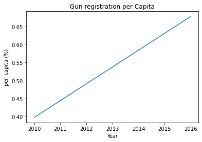

```python
# Plot the graph of Gun per capital over the years 2010 and 2016

year = [2010, 2016]
percent_per_capita = [percentage10, percentage16]

plt.title('Gun registration per Capita')
plt.xlabel('Year')
plt.ylabel('per_capita (%)')
plt.plot(year, percent_per_capita)
# plt.show()
```

### Research Question 2 : Which gun tyoe of gun was ordered mostly?

```python
# since there are four types of firearms
#create a list of the firearms types
gun_type= ['handgun', 'long_gun', 'other', 'multiple']
```

```python
handgun_total = clean_gun_data['handgun'].sum()
```

```python
long_gun_total = clean_gun_data['long_gun'].sum()
```

```python
other_total = clean_gun_data['other'].sum()
```

```python
multiple_total = clean_gun_data['multiple'].sum()
```

```python
sum_total = [handgun_total, long_gun_total, other_total, multiple_total]
```

```python
def Million(type1, pos):
    'This function covert the 10e6 to million'
    return '%1.1fM' % (type1 * 1e-6)
```

```
<BarContainer object of 4 artists>
```

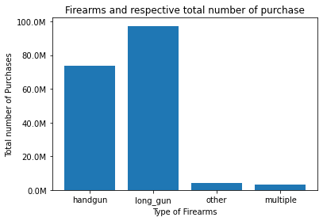

```python
# plot the number of purchae of the types of gun
import matplotlib.ticker as tick
fig, ax = plt.subplots()
ax.yaxis.set_major_formatter(tick.FuncFormatter(Million))
plt.title('Firearms and respective total number of purchase')
plt.ylabel('Total number of Purchases')
plt.xlabel('Type of Firearms')
plt.bar(gun_type, sum_total)
```

The most purchased gun over the years is long_gun

### Research Question 3 : Is there a seasonal pattern for firearm shopping?

```python
# extract column month and total from the cleaned gun data
df_gun_total = clean_gun_data[['month', 'totals']]
df_gun_total
```

|  | month | totals |
| --- | --- | --- |
| 0 | 2017-09 | 32019.0 |
| 1 | 2017-09 | 6303.0 |
| 2 | 2017-09 | 28394.0 |
| 3 | 2017-09 | 17747.0 |
| 4 | 2017-09 | 123506.0 |
| ... | ... | ... |
| 12480 | 1998-11 | 24.0 |
| 12481 | 1998-11 | 361.0 |
| 12482 | 1998-11 | 408.0 |
| 12483 | 1998-11 | 241.0 |
| 12484 | 1998-11 | 107.0 |

11350 rows × 2 columns

```python
# group the extracted date and total column by the month
GroupByMonth = df_gun_total.groupby('month').sum()
GroupByMonth
```

| month | totals |
| --- | --- |
| 1998-11 | 21174.0 |
| 1998-12 | 870202.0 |
| 1999-01 | 585569.0 |
| 1999-02 | 689867.0 |
| 1999-03 | 741234.0 |
| ... | ... |
| 2017-05 | 1896910.0 |
| 2017-06 | 1886240.0 |
| 2017-07 | 1731550.0 |
| 2017-08 | 1894569.0 |
| 2017-09 | 1856214.0 |

227 rows × 1 columns

```
[]
```

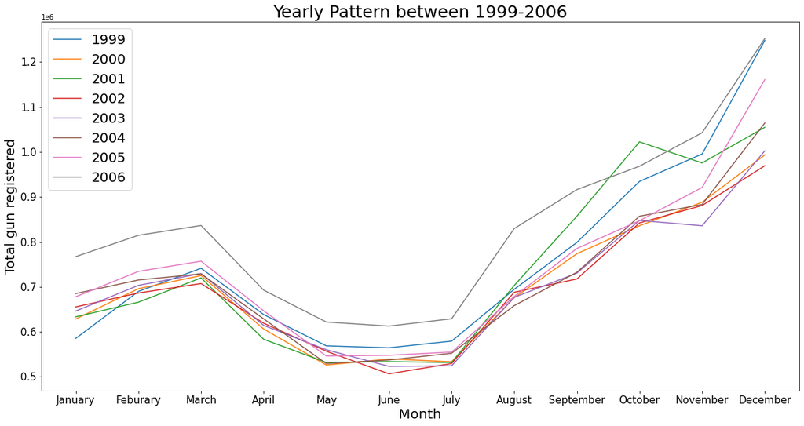

```python
# plot the yearly pattern of the total sales of gun between year 1999-2006
ax = GroupByMonth.loc['1999':'2000'].plot(figsize=(20,10),fontsize=15) #add the year 1999's plot first
legend =['1999']
for i in range(2000,2007): #since the data in year 1998 is not complete, it will be excluded
    ax = GroupByMonth.loc[str(i):str(i+1)].plot(ax=ax)
    legend.append(str(i))
ax.legend(legend,fontsize=20)
ax.set_xticks(np.arange(12))
ax.set_xticklabels(pd.Series(['January','Feburary','March','April','May','June','July','August','September','October','November','December']),fontdict={
     'fontsize': 15,
     'fontweight': 15})
ax.set_title('Yearly Pattern between 1999-2006', fontsize=25)
ax.set_xlabel('Month', fontsize=20)
ax.set_ylabel('Total gun registered', fontsize=20)
ax.plot()
```

```
[]
```

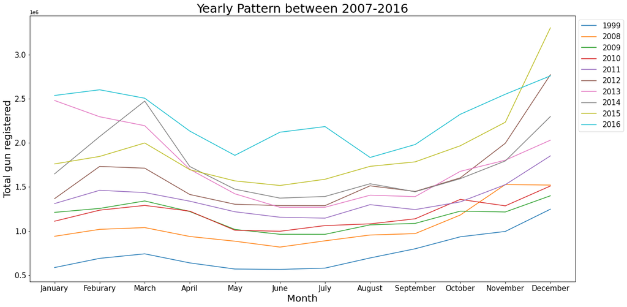

```python
# plot the yearly pattern of the total sales of gun between year 2007-2016

ax = GroupByMonth.loc['1999':'2000'].plot(figsize=(20,10),fontsize=15) #add the year 1999's plot first
legend =['1999']
for i in range(2008,2017): #year 2017 is excluded
    ax = GroupByMonth.loc[str(i):str(i+1)].plot(ax=ax)
    legend.append(str(i))
# ax.legend(legend,loc='upper right',fontsize=15)
ax.legend(legend,bbox_to_anchor=(1,1),fontsize=15)

ax.set_xticks(np.arange(12))
ax.set_xticklabels(pd.Series(['January','Feburary','March','April','May','June','July','August','September','October','November','December']),fontdict={
     'fontsize': 15,
     'fontweight': 15})
ax.set_title('Yearly Pattern between 2007-2016', fontsize=25)
ax.set_xlabel('Month', fontsize=20)
ax.set_ylabel('Total gun registered', fontsize=20)
ax.plot()
```

The plot shows that from 1999 to 2016, there is a significant pattern in which the total number of background checks remains low during the summer and peaks in the winter. So, the answer to this research question is: Yes, there is a seasonal pattern for background checks and, consequently, for firearm shopping.

One thing to note is that the 2016 numbers have a slightly higher peak during the summer than previous years, implying that more research is needed. A good question to ask is whether or not there has been a change in gun control regulations..

### Research Question 4 : Which states have had the highest growth in gun registrations?

```python
#List 10 states with high gun in 2010
gun_2010.sort_values(by=['totals_gun10'], axis = 0, ascending = False).head(10)
```

|  | date_gun10 | state | totals_gun10 |
| --- | --- | --- | --- |
| 4913 | 2010-04-01 | Kentucky | 211261.0 |
| 4942 | 2010-04-01 | Utah | 109391.0 |
| 4899 | 2010-04-01 | California | 80750.0 |
| 4941 | 2010-04-01 | Texas | 65012.0 |
| 4909 | 2010-04-01 | Illinois | 53929.0 |
| 4935 | 2010-04-01 | Pennsylvania | 50249.0 |
| 4945 | 2010-04-01 | Virginia | 44137.0 |
| 4904 | 2010-04-01 | Florida | 42794.0 |
| 4932 | 2010-04-01 | Ohio | 31312.0 |
| 4940 | 2010-04-01 | Tennessee | 30453.0 |

Kentucky, Utah, California, Texas, Illinois, Pennsylvania, Virginia, Florida, Ohio, and Tennessee were among the ten states with the highest gun registration rates in 2010.

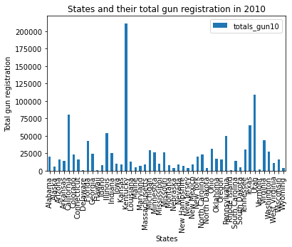

```python
#plot states with their total registration gun in 2010
gun_2010.plot(x='state', y='totals_gun10', kind='bar')
plt.title('States and their total gun registration in 2010')
plt.xlabel('States')
plt.ylabel('Total gun registration')
```

```python
#List 10 states with high gun in 2016
gun_2016.sort_values(by=['totals_gun16'], axis = 0, ascending = False).head(10)
```

|  | date_gun16 | state | totals_gun16 |
| --- | --- | --- | --- |
| 788 | 2016-07-01 | Kentucky | 363085.0 |
| 774 | 2016-07-01 | California | 190218.0 |
| 784 | 2016-07-01 | Illinois | 168227.0 |
| 816 | 2016-07-01 | Texas | 127207.0 |
| 779 | 2016-07-01 | Florida | 125208.0 |
| 785 | 2016-07-01 | Indiana | 88340.0 |
| 810 | 2016-07-01 | Pennsylvania | 86137.0 |
| 807 | 2016-07-01 | Ohio | 63148.0 |
| 815 | 2016-07-01 | Tennessee | 57653.0 |
| 780 | 2016-07-01 | Georgia | 49183.0 |

In year 20216, Kentucky, California, Illinois, Texas, Florida, Indiana, Pennsylvania, Ohio, Tennessee, and Georgia were the 10 states that had a very high total of gun registrations.

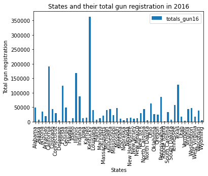

```python
#plot states with their total registration gun in 2016
gun_2016.plot(x='state', y='totals_gun16', kind='bar')
plt.title('States and their total gun registration in 2016')
plt.xlabel('States')
plt.ylabel('Total gun registration')
```

```python
# check the increase of gun registration in each states
combined_gun['gun_growth'] = (combined_gun['totals_gun16']-combined_gun['totals_gun10'])/combined_gun['totals_gun10']
combined_gun.head()
```

|  | date_gun10 | state | totals_gun10 | date_gun16 | totals_gun16 | gun_growth |
| --- | --- | --- | --- | --- | --- | --- |
| 0 | 2010-04-01 | Alabama | 20791.0 | 2016-07-01 | 48927.0 | 1.353278 |
| 1 | 2010-04-01 | Alaska | 6411.0 | 2016-07-01 | 6793.0 | 0.059585 |
| 2 | 2010-04-01 | Arizona | 16578.0 | 2016-07-01 | 34496.0 | 1.080830 |
| 3 | 2010-04-01 | Arkansas | 14563.0 | 2016-07-01 | 19378.0 | 0.330632 |
| 4 | 2010-04-01 | California | 80750.0 | 2016-07-01 | 190218.0 | 1.355641 |

```python
# check the first 10 states with highest growth in gun registrations
combined_gun.sort_values(by=['gun_growth'], axis = 0, ascending = False).head(10)
```

|  | date_gun10 | state | totals_gun10 | date_gun16 | totals_gun16 | gun_growth |
| --- | --- | --- | --- | --- | --- | --- |
| 13 | 2010-04-01 | Indiana | 25232.0 | 2016-07-01 | 88340.0 | 2.501110 |
| 7 | 2010-04-01 | Delaware | 1439.0 | 2016-07-01 | 4494.0 | 2.123002 |
| 12 | 2010-04-01 | Illinois | 53929.0 | 2016-07-01 | 168227.0 | 2.119416 |
| 17 | 2010-04-01 | Louisiana | 13373.0 | 2016-07-01 | 41063.0 | 2.070590 |
| 8 | 2010-04-01 | Florida | 42794.0 | 2016-07-01 | 125208.0 | 1.925831 |
| 29 | 2010-04-01 | New Jersey | 4215.0 | 2016-07-01 | 10074.0 | 1.390036 |
| 48 | 2010-04-01 | Wisconsin | 16471.0 | 2016-07-01 | 38922.0 | 1.363062 |
| 4 | 2010-04-01 | California | 80750.0 | 2016-07-01 | 190218.0 | 1.355641 |
| 0 | 2010-04-01 | Alabama | 20791.0 | 2016-07-01 | 48927.0 | 1.353278 |
| 20 | 2010-04-01 | Massachusetts | 8748.0 | 2016-07-01 | 20480.0 | 1.341107 |

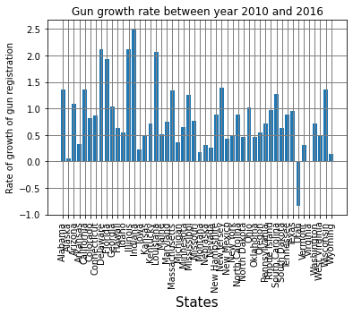

```python
# plot the growth rate in gun registrations of each states
plt.bar(combined_gun['state'],combined_gun['gun_growth'])
plt.grid(color='grey', linestyle='-', linewidth=1)
plt.title('Gun growth rate between year 2010 and 2016')
plt.xlabel('States', fontsize = 15)
plt.ylabel('Rate of growth of gun registration')
plt.xticks(combined_gun['state'], rotation=90)
plt.grid(color='grey', linestyle='-', linewidth=1)
```

Indiana has the highest rate of growth among all states in the United States of America.

### Research Question 5 : What is the overall trend of gun purchases?

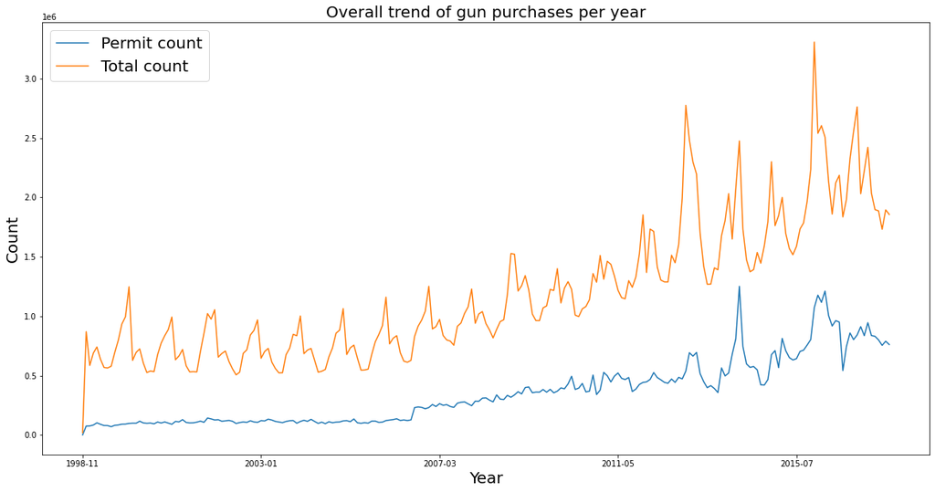

```python
plt.figure(figsize=(20,10))
clean_gun_data.groupby('month')['permit'].sum().plot(kind='line',sharex=True, sharey=True, layout = (2, 1),label = 'Permit count')
clean_gun_data.groupby('month')['totals'].sum().plot(kind='line',sharex=True, sharey=True, layout = (3, 2),label = 'Total count')
plt.title('Overall trend of gun purchases per year',fontsize = 20)
plt.xlabel('Year',fontsize = 20)
plt.ylabel('Count',fontsize = 20)
plt.legend(fontsize = 20)
plt.show()
```

```python
# Extract year
clean_gun_data['year']=pd.DatetimeIndex(clean_gun_data['month']).year
```

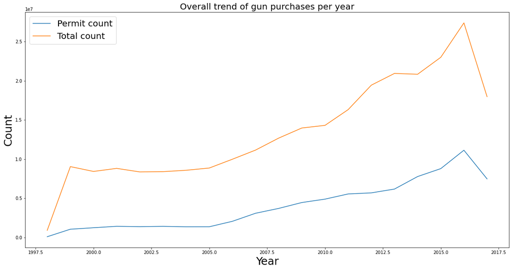

```python
plt.figure(figsize=(20,10))
clean_gun_data.groupby('year')['permit'].sum().plot(kind='line',sharex=True, sharey=True, layout = (2, 1),label = 'Permit count')
clean_gun_data.groupby('year')['totals'].sum().plot(kind='line',sharex=True, sharey=True, layout = (3, 2),label = 'Total count')
plt.title('Overall trend of gun purchases per year',fontsize = 20)
plt.xlabel('Year',fontsize = 25)
plt.ylabel('Count',fontsize = 25)
plt.legend(fontsize = 20)
plt.show()
```

## Conclusions

> According to the analysis, gun registration per capita was 0.39781331523550745 percent in 2010 and 0.677793404977627 percent in 2016. And this demonstrates that gun registration per capita has increased by roughly 70% since 2010.

> Furthermore, states such as Kentucky, California, Texas, Illinois, Pennsylvania, Ohio, and Tennessee maintained their position as the top states with high gun registration between 2010 and 2016. Furthermore, long guns are the most common type of firearm purchased by Americans over the years, followed by hand guns.

> The number of gun registrations has increased in every state except Utah, according to positive growth in gun registrations. Indiana has the highest growth rate of any state in the United States of America, at 250 percent. This could indicate that they are outliers, that there is increased reliance and trust in firearms, as well as decreased trust in police institutions, or that there are increased safety concerns for a variety of reasons.

> The year-to-year comparisons of all states between 1999 and 2016 show that the number remains low in the summer and peaks in the winter. There was some inconsistency during the summer of 2016, which we need to investigate further.

## General Resources

1. https://matplotlib.org/3.3.2/index.html
2. https://pandas.pydata.org/pandas-docs/stable/index.html